# Assignment 4: ANOVA Testing & Bootstrapping

Univeristy of Washington - Data Science Certification - Method for Data Analysis

Josh Jensen

July 27, 2016

### Assignment

1. Compare the price (log price) of autos for several multi*valued categorical variables
   - number of doors
   - body style
   - drive wheels
   - number of cylinders
   - engine type
2. Graphically explore the differences
3. Use standard ANOVA and Tukey ANOVA in R
4. Use the bootstrap distribution CIs of the differences of means

### Conclusions

We find statistically significant differences in log price among:

- body style
  - between hatchback & convertible, hatchback & hardtop, and sedan & hatchback.
- drive wheels
  - between RWD & 4WD as well as RWD & FWD
- number of cylinders
  - between several combinations
- engine type
  - between several combinations

However we observe no significant difference within log price by:

- number of doors

### Set up & cleaning

Load libraries and data.

```r
# load libraries and set working drive
library(dplyr)
library(readr)
library(ggplot2)
library(simpleboot)
library(combinat)

# read in data
auto_prices <- read_csv('Automobile price data _Raw_.csv', na = c('','?'))
```

Clean data set to make it easier to work with and inspect.

```r
# rename columns
colnames(auto_prices) <- gsub('-','_', colnames(auto_prices))

# subset down to columns of interest
# price, number of doors, body style, drive wheels, number of cylinders, engine type
vars <- c("num_of_doors", "body_style", "drive_wheels", "num_of_cylinders", "engine_type")
auto_prices <- select(auto_prices, price, one_of(vars))

# set to factor
auto_prices[vars] <- lapply(auto_prices[vars], as.factor)

# create log price
auto_prices$log_price <- log(auto_prices$price)

# final inspection of structure
str(auto_prices)
```

```
## Classes 'tbl_df', 'tbl' and 'data.frame':    205 obs. of  7 variables:
##  $ price           : int  13495 16500 16500 13950 17450 15250 17710 18920 23875 NA ...
##  $ num_of_doors    : Factor w/ 2 levels "four","two": 2 2 2 1 1 2 1 1 1 2 ...
##  $ body_style      : Factor w/ 5 levels "convertible",..: 1 1 3 4 4 4 4 5 4 3 ...
##  $ drive_wheels    : Factor w/ 3 levels "4wd","fwd","rwd": 3 3 3 2 1 2 2 2 2 1 ...
##  $ num_of_cylinders: Factor w/ 7 levels "eight","five",..: 3 3 4 3 2 2 2 2 2 2 ...
##  $ engine_type     : Factor w/ 7 levels "dohc","dohcv",..: 1 1 6 4 4 4 4 4 4 4 ...
##  $ log_price       : num  9.51 9.71 9.71 9.54 9.77 ...
```

### Compare differences in log prices

First lets loop through each variable, comparing the means of each factor level.

```r
# compare the means
for (i in 1:length(vars)) {
  temp <- auto_prices %>%
              group_by_(vars[i]) %>%
              summarise(mean_log_price = mean(log_price, na.rm=T), n = n())
  print(temp)
}
```

```
## Source: local data frame [3 x 3]
##
##   num_of_doors mean_log_price     n
##         (fctr)          (dbl) (int)
## 1         four       9.396764   114
## 2          two       9.292991    89
## 3           NA       9.170730     2
## Source: local data frame [5 x 3]
##
##    body_style mean_log_price     n
##        (fctr)          (dbl) (int)
## 1 convertible       9.890536     6
## 2     hardtop       9.793886     8
## 3   hatchback       9.127714    70
## 4       sedan       9.438602    96
## 5       wagon       9.350626    25
## Source: local data frame [3 x 3]
##
##   drive_wheels mean_log_price     n
##         (fctr)          (dbl) (int)
## 1          4wd       9.196609     9
## 2          fwd       9.077632   120
## 3          rwd       9.795195    76
## Source: local data frame [7 x 3]
##
##   num_of_cylinders mean_log_price     n
##             (fctr)          (dbl) (int)
## 1            eight      10.561958     5
## 2             five       9.960941    11
## 3             four       9.174748   159
## 4              six      10.007616    24
## 5            three       8.546946     1
## 6           twelve      10.491274     1
## 7              two       9.464834     4
## Source: local data frame [7 x 3]
##
##   engine_type mean_log_price     n
##        (fctr)          (dbl) (int)
## 1        dohc       9.728366    12
## 2       dohcv            NaN     1
## 3           l       9.546869    12
## 4         ohc       9.241706   148
## 5        ohcf       9.312102    15
## 6        ohcv      10.037075    13
## 7       rotor       9.464834     4
```

Now lets get an idea of the differences in distributions by looking at boxplots for each variable.

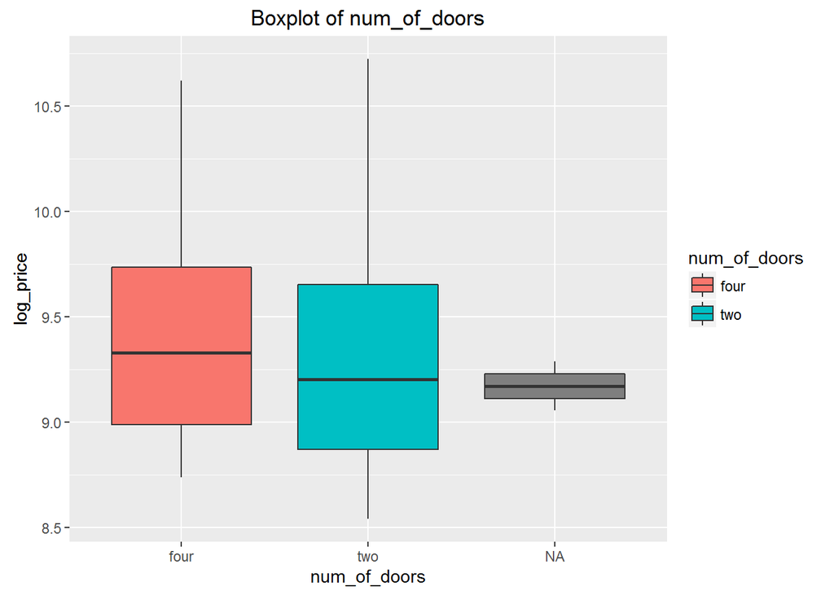

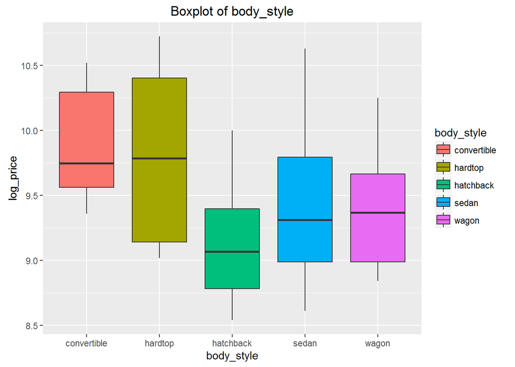

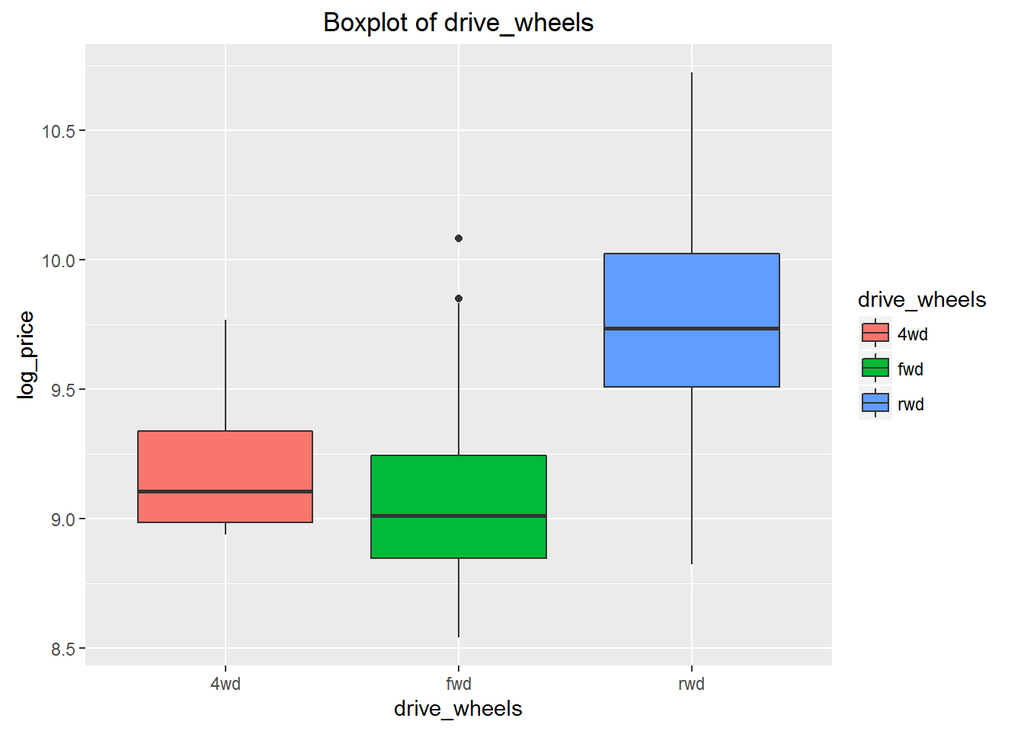

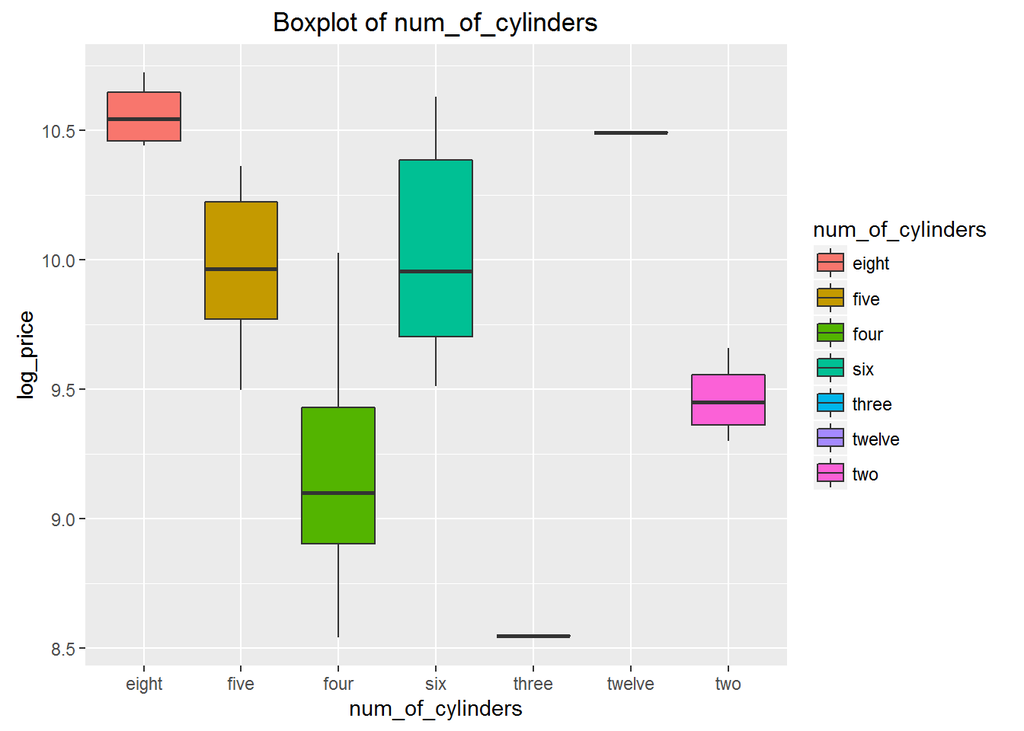

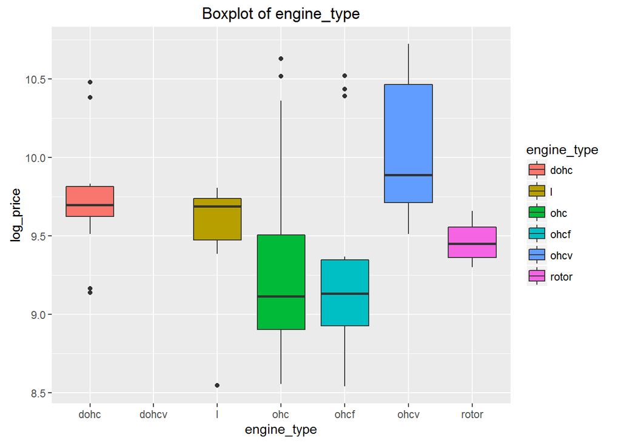

```r
# inspect boxplots
for (i in 1:length(vars)) {
  p <- ggplot(auto_prices, aes_string(x=vars[i], y="log_price", fill=vars[i])) +
    geom_boxplot() +
    ggtitle(paste("Boxplot of",vars[i]))
  print(p)
}
```

### ANOVA Tests on Group Differences

Now lets test whether or not the differences in log price are due to error or not. To do this we will use the an ANOVA test, then inspect the individual differences with a Tukey ANOVA test. Lets make a function so that we can call any variable.

```r
log_price_anova <- function(factor_vector) {
  # run anova
  anova_test <- aov(auto_prices$log_price ~ factor_vector)
  # print results
  writeLines("ANOVA TEST:\n")
  print(summary(anova_test))

  # run tukey anova on anova output
  tukey_anova <- TukeyHSD(anova_test)
  # print results
  writeLines("\n\n\nTUKEY ANOVA TEST:\n")
  print(tukey_anova)

  # plot tukey anova difference in means plot for 95% confidence
  plot(tukey_anova)
}
```

#### Number of doors

```r
log_price_anova(auto_prices$num_of_doors)
```

```
## ANOVA TEST:
##
##                Df Sum Sq Mean Sq F value Pr(>F)
## factor_vector   1   0.53  0.5259   2.079  0.151
## Residuals     197  49.83  0.2530
## 6 observations deleted due to missingness
##
##
##
## TUKEY ANOVA TEST:
##
##   Tukey multiple comparisons of means
##     95% family-wise confidence level
##
## Fit: aov(formula = auto_prices$log_price ~ factor_vector)
##
## $factor_vector
##                diff        lwr        upr     p adj
## two-four -0.1037724 -0.2457075 0.03816267 0.1509359
```

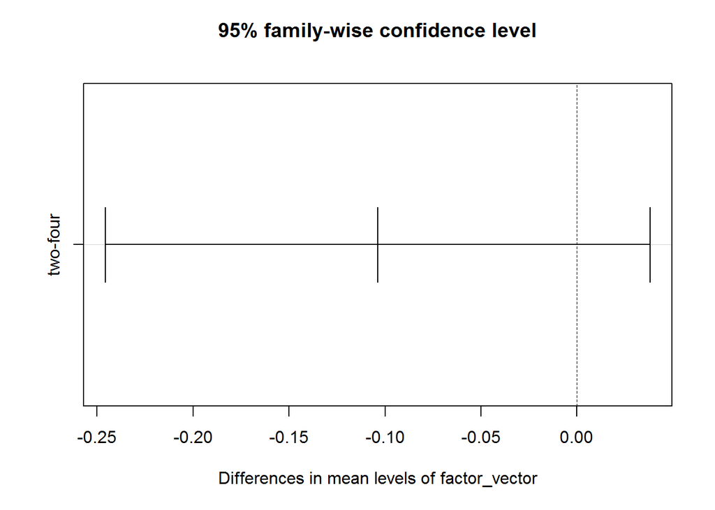

We fail to reject the null hypothesis that there is any difference within log price by number of doors.

#### Body style

```r
log_price_anova(auto_prices$body_style)
```

```
## ANOVA TEST:
##
##                Df Sum Sq Mean Sq F value   Pr(>F)
## factor_vector   4   7.43  1.8568   8.459 2.57e-06 ***
## Residuals     196  43.02  0.2195
## ---
## Signif. codes:  0 '***' 0.001 '**' 0.01 '*' 0.05 '.' 0.1 ' ' 1
## 4 observations deleted due to missingness
##
##
##
## TUKEY ANOVA TEST:
##
##   Tukey multiple comparisons of means
##     95% family-wise confidence level
##
## Fit: aov(formula = auto_prices$log_price ~ factor_vector)
##
## $factor_vector
##                              diff         lwr         upr     p adj
## hardtop-convertible   -0.09664988 -0.79332571  0.60002595 0.9954531
## hatchback-convertible -0.76282276 -1.31220310 -0.21344241 0.0016444
## sedan-convertible     -0.45193455 -0.99511958  0.09125047 0.1522341
## wagon-convertible     -0.53991067 -1.12634928  0.04652795 0.0871629
## hatchback-hardtop     -0.66617287 -1.14833677 -0.18400898 0.0017630
## sedan-hardtop         -0.35528467 -0.83037754  0.11980819 0.2422707
## wagon-hardtop         -0.44326078 -0.96725840  0.08073684 0.1401145
## sedan-hatchback        0.31088820  0.10552318  0.51625322 0.0004392
## wagon-hatchback        0.22291209 -0.07880809  0.52463227 0.2536491
## wagon-sedan           -0.08797611 -0.37826265  0.20231042 0.9196125
```

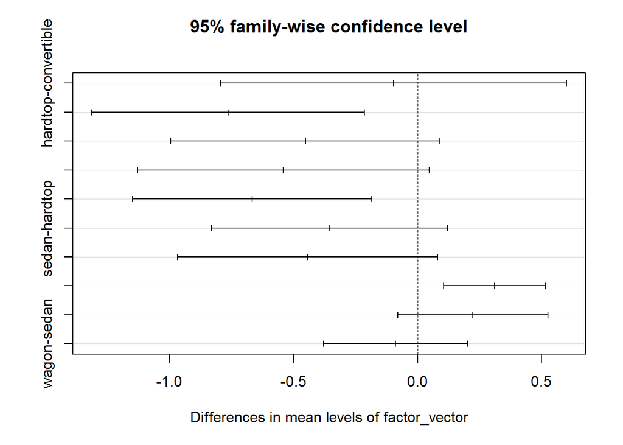

We reject the null hypothesis that there is any difference within log price by body style. Statistically significant differences exist between hatchback & convertible, hatchback & hardtop, and sedan & hatchback.

#### Drive wheels

```r
log_price_anova(auto_prices$drive_wheels)
```

```
## ANOVA TEST:
##
##                Df Sum Sq Mean Sq F value Pr(>F)
## factor_vector   2  23.81  11.903   88.46 <2e-16 ***
## Residuals     198  26.64   0.135
## ---
## Signif. codes:  0 '***' 0.001 '**' 0.01 '*' 0.05 '.' 0.1 ' ' 1
## 4 observations deleted due to missingness
##
##
##
## TUKEY ANOVA TEST:
##
##   Tukey multiple comparisons of means
##     95% family-wise confidence level
##
## Fit: aov(formula = auto_prices$log_price ~ factor_vector)
##
## $factor_vector
##               diff        lwr       upr     p adj
## fwd-4wd -0.1189779 -0.4354627 0.1975069 0.6486603
## rwd-4wd  0.5985857  0.2763921 0.9207794 0.0000552
## rwd-fwd  0.7175636  0.5896371 0.8454901 0.0000000
```

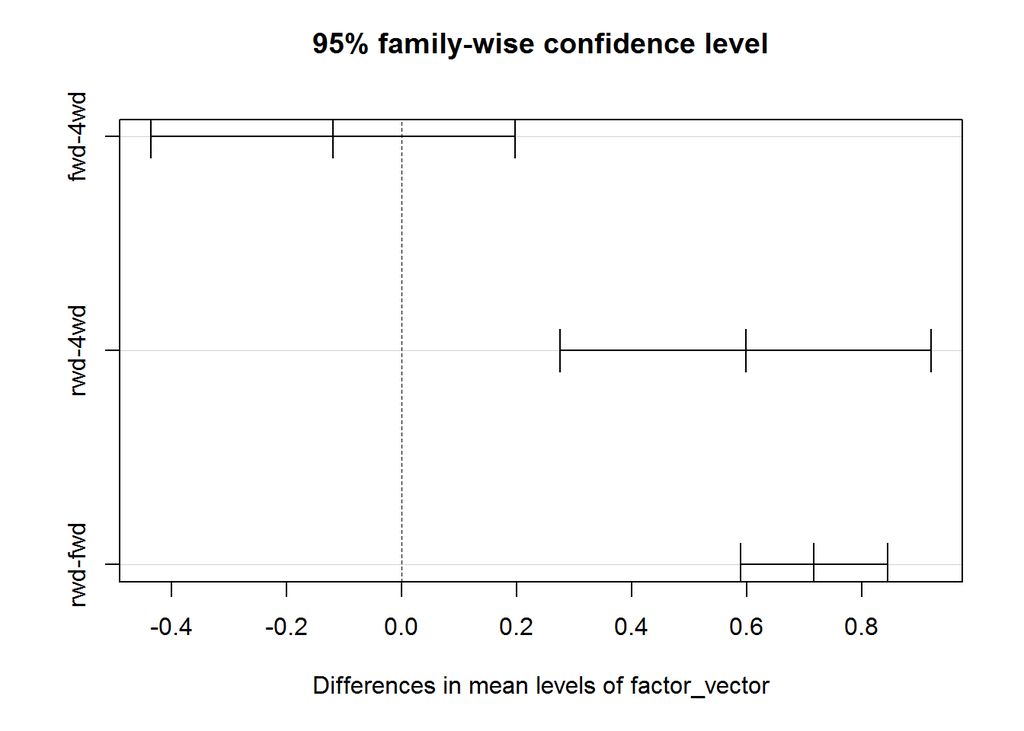

We reject the null hypothesis that there is any difference within log price by drive wheels. Statistically significant differences exist between RWD & 4WD as well as RWD & FWD.

#### Number of cylinders

```r
log_price_anova(auto_prices$num_of_cylinders)
```

```
## ANOVA TEST:
##
##                Df Sum Sq Mean Sq F value Pr(>F)
## factor_vector   6  26.81   4.468   36.66 <2e-16 ***
## Residuals     194  23.64   0.122
## ---
## Signif. codes:  0 '***' 0.001 '**' 0.01 '*' 0.05 '.' 0.1 ' ' 1
## 4 observations deleted due to missingness
##
##
##
## TUKEY ANOVA TEST:
##
##   Tukey multiple comparisons of means
##     95% family-wise confidence level
##
## Fit: aov(formula = auto_prices$log_price ~ factor_vector)
##
## $factor_vector
##                     diff        lwr          upr     p adj
## five-eight   -0.60101774 -1.2163750  0.014339517 0.0604547
## four-eight   -1.38721019 -1.9138654 -0.860554934 0.0000000
## six-eight    -0.55434264 -1.1160844  0.007399116 0.0557024
## three-eight  -2.01501227 -3.1779282 -0.852096362 0.0000124
## twelve-eight -0.07068420 -1.2336001  1.092231706 0.9999970
## two-eight    -1.09712487 -1.8326175 -0.361632267 0.0002945
## four-five    -0.78619245 -1.1254283 -0.446956618 0.0000000
## six-five      0.04667511 -0.3448207  0.438170937 0.9998373
## three-five   -1.41399453 -2.5049064 -0.323082708 0.0028764
## twelve-five   0.53033354 -0.5605783  1.621245360 0.7745911
## two-five     -0.49610713 -1.1114644  0.119250133 0.2033053
## six-four      0.83286755  0.6048978  1.060837261 0.0000000
## three-four   -0.62780208 -1.6712530  0.415648828 0.5546261
## twelve-four   1.31652599  0.2730751  2.359976896 0.0041696
## two-four      0.29008532 -0.2365699  0.816740576 0.6558237
## three-six    -1.46066963 -2.5222618 -0.399077508 0.0011749
## twelve-six    0.48365843 -0.5779337  1.545250560 0.8234782
## two-six      -0.54278223 -1.1045240  0.018959522 0.0657085
## twelve-three  1.94432807  0.4733429  3.415313268 0.0021690
## two-three     0.91788740 -0.2450285  2.080803313 0.2252326
## two-twelve   -1.02644066 -2.1893566  0.136475246 0.1228005
```

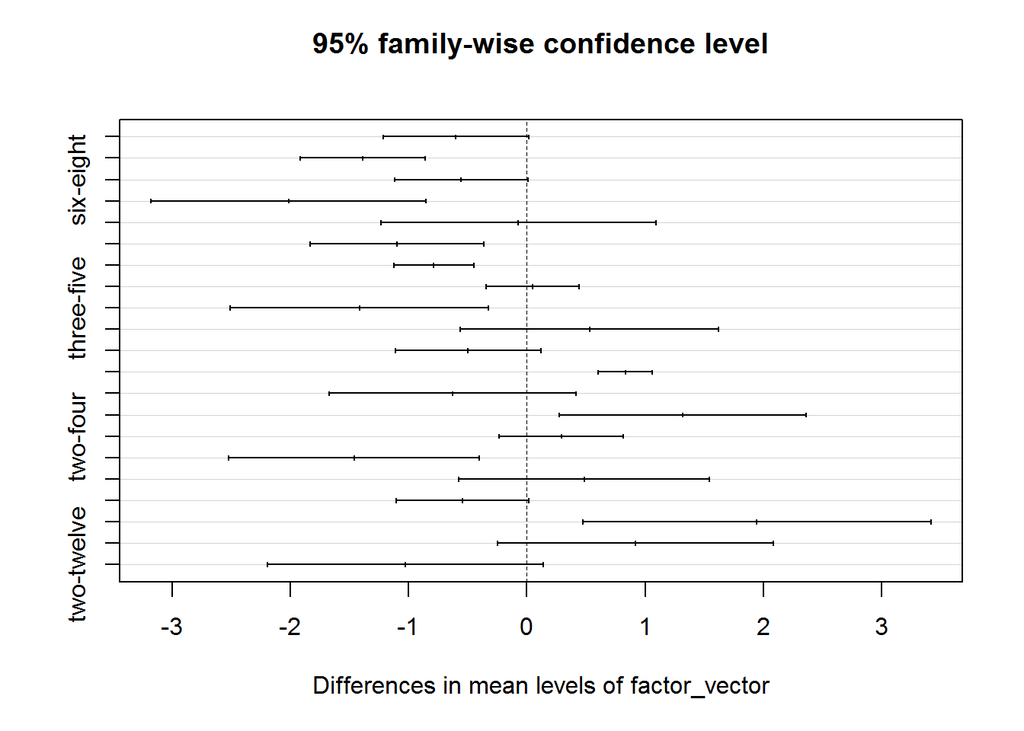

We reject the null hypothesis that there is any difference within log price by number of cylinders. Statistically significant differences exist for several combinations.

#### Engine type

```r
log_price_anova(auto_prices$engine_type)
```

```
## ANOVA TEST:
##
##                Df Sum Sq Mean Sq F value   Pr(>F)
## factor_vector   5  10.09   2.019   9.755 2.47e-08 ***
## Residuals     195  40.36   0.207
## ---
## Signif. codes:  0 '***' 0.001 '**' 0.01 '*' 0.05 '.' 0.1 ' ' 1
## 4 observations deleted due to missingness
##
##
##
## TUKEY ANOVA TEST:
##
##   Tukey multiple comparisons of means
##     95% family-wise confidence level
##
## Fit: aov(formula = auto_prices$log_price ~ factor_vector)
##
## $factor_vector
##                   diff         lwr         upr     p adj
## l-dohc     -0.18149661 -0.71605620  0.35306298 0.9246905
## ohc-dohc   -0.48665952 -0.87998035 -0.09333869 0.0060971
## ohcf-dohc  -0.41626362 -0.92339137  0.09086413 0.1747908
## ohcv-dohc   0.30870901 -0.21546979  0.83288781 0.5366660
## rotor-dohc -0.26353213 -1.01951354  0.49244929 0.9163894
## ohc-l      -0.30516291 -0.69848374  0.08815792 0.2274586
## ohcf-l     -0.23476701 -0.74189476  0.27236074 0.7666390
## ohcv-l      0.49020562 -0.03397318  1.01438442 0.0815071
## rotor-l    -0.08203552 -0.83801693  0.67394590 0.9995986
## ohcf-ohc    0.07039590 -0.28474616  0.42553796 0.9928163
## ohcv-ohc    0.79536853  0.41627653  1.17446052 0.0000001
## rotor-ohc   0.22312739 -0.44054062  0.88679541 0.9275951
## ohcv-ohcf   0.72497263  0.22879925  1.22114601 0.0005609
## rotor-ohcf  0.15273150 -0.58410805  0.88957104 0.9911679
## rotor-ohcv -0.57224113 -1.32091821  0.17643594 0.2425085
```

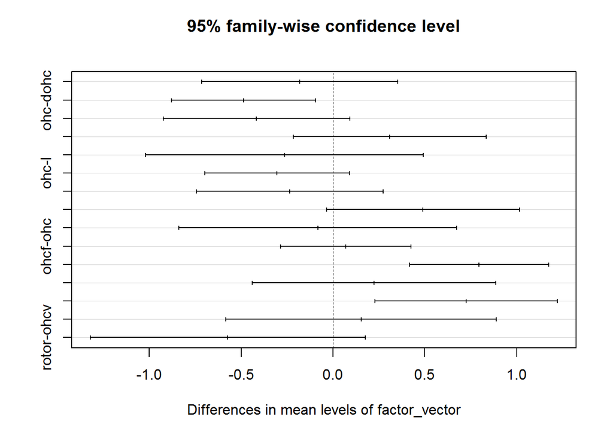

We reject the null hypothesis that there is any difference within log price by engine type. Statistically significant differences exist for several combinations.

### Bootstrap distribution confidence intervals

To further verify our conclusions, using a bootstraped generated distribution we generate confidence intervals in the differences in means between two factor values. We create 10,000 independent resamples with replacement for each factor value that has more than 10 observations.

If 0 lies within the confidence interval of the differences of means, then we conclude that there is no difference in the log price between the two factor values in question.

```r
boot_factor_diff_in_means_log_price <- function(factor_vector, replicates = 10000, alpha = .05) {

  # use combn to output all distinct combinations of n levels of factor, with choose 2

  if (length(levels(factor_vector)) > 2) {
    combinations <- combn(levels(factor_vector), 2)
  } else if (length(levels(factor_vector)) == 2) {
    combinations <- matrix(c(levels(factor_vector)[1], levels(factor_vector)[2]), nrow = 2, ncol = 1)
  } else {
    stop()
  }

  # loop through all distinct combinations
  for (i in 1:ncol(combinations)) {

    # filter
    df1 <- auto_prices[factor_vector == combinations[1,i],]
    df2 <- auto_prices[factor_vector == combinations[2,i],]

    # skip bootstrapping if either has less than 10 observations
    if ((nrow(df1)>10) & (nrow(df2)>10)) {
      # run bootstrap
      boot <- two.boot(na.omit(df1$log_price), na.omit(df2$log_price), mean, R = replicates)

      # print results
      writeLines(paste("\n\n\nDifference between", combinations[1,i], "and", combinations[2,i]))
      print(paste0("with confidence interval of ", 100 * (1 - .05), "%"))
      print("")
      print(paste("LOWER BOUND: ", quantile(boot$t, alpha/2)))
      print(paste("MEAN DIFF:   ", mean(boot$t)))
      print(paste("UPPER BOUND: ", quantile(boot$t, 1-(alpha/2))))
    }
  }
}
```

#### Number of doors

```r
boot_factor_diff_in_means_log_price(auto_prices$num_of_doors)
```

```
##
##
##
## Difference between four and two
## [1] "with confidence interval of 95%"
## [1] ""
## [1] "LOWER BOUND:  -0.0416481446357034"
## [1] "MEAN DIFF:    0.102845781098736"
## [1] "UPPER BOUND:  0.245804263236385"
```

#### Body style

```r
boot_factor_diff_in_means_log_price(auto_prices$body_style)
```

```
##
##
##
## Difference between hatchback and sedan
## [1] "with confidence interval of 95%"
## [1] ""
## [1] "LOWER BOUND:  -0.451456440624703"
## [1] "MEAN DIFF:    -0.311486257578882"
## [1] "UPPER BOUND:  -0.176612653127355"
##
##
##
## Difference between hatchback and wagon
## [1] "with confidence interval of 95%"
## [1] ""
## [1] "LOWER BOUND:  -0.399957281284693"
## [1] "MEAN DIFF:    -0.222997074807626"
## [1] "UPPER BOUND:  -0.0505277328127226"
##
##
##
## Difference between sedan and wagon
## [1] "with confidence interval of 95%"
## [1] ""
## [1] "LOWER BOUND:  -0.0896833537695385"
## [1] "MEAN DIFF:    0.089545503779655"
## [1] "UPPER BOUND:  0.268630303625739"
```

#### Drive wheels

```r
boot_factor_diff_in_means_log_price(auto_prices$drive_wheels)
```

```
##
##
##
## Difference between fwd and rwd
## [1] "with confidence interval of 95%"
## [1] ""
## [1] "LOWER BOUND:  -0.831365893889641"
## [1] "MEAN DIFF:    -0.718029293757753"
## [1] "UPPER BOUND:  -0.6049504228134"
```

#### Number of cylinders

```r
boot_factor_diff_in_means_log_price(auto_prices$num_of_cylinders)
```

```
##
##
##
## Difference between five and four
## [1] "with confidence interval of 95%"
## [1] ""
## [1] "LOWER BOUND:  0.606425831304023"
## [1] "MEAN DIFF:    0.786911544811239"
## [1] "UPPER BOUND:  0.966944551435238"
##
##
##
## Difference between five and six
## [1] "with confidence interval of 95%"
## [1] ""
## [1] "LOWER BOUND:  -0.270777598414817"
## [1] "MEAN DIFF:    -0.0470816294497129"
## [1] "UPPER BOUND:  0.175999831706867"
##
##
##
## Difference between four and six
## [1] "with confidence interval of 95%"
## [1] ""
## [1] "LOWER BOUND:  -0.989280864228674"
## [1] "MEAN DIFF:    -0.832570890298245"
## [1] "UPPER BOUND:  -0.685475633127755"
```

#### Engine type

```r
boot_factor_diff_in_means_log_price(auto_prices$engine_type)
```

```
##
##
##
## Difference between dohc and l
## [1] "with confidence interval of 95%"
## [1] ""
## [1] "LOWER BOUND:  -0.0843727704742064"
## [1] "MEAN DIFF:    0.181150408162291"
## [1] "UPPER BOUND:  0.481391474087125"
##
##
##
## Difference between dohc and ohc
## [1] "with confidence interval of 95%"
## [1] ""
## [1] "LOWER BOUND:  0.263176420635177"
## [1] "MEAN DIFF:    0.484988187879219"
## [1] "UPPER BOUND:  0.717697744159913"
##
##
##
## Difference between dohc and ohcf
## [1] "with confidence interval of 95%"
## [1] ""
## [1] "LOWER BOUND:  0.0294403412862629"
## [1] "MEAN DIFF:    0.416431806674041"
## [1] "UPPER BOUND:  0.781338588133632"
##
##
##
## Difference between dohc and ohcv
## [1] "with confidence interval of 95%"
## [1] ""
## [1] "LOWER BOUND:  -0.621338455950934"
## [1] "MEAN DIFF:    -0.309564162680426"
## [1] "UPPER BOUND:  0.0139099937444931"
##
##
##
## Difference between l and ohc
```

[output cut: 35 more lines]

```
## Difference between ohc and ohcv
## [1] "with confidence interval of 95%"
## [1] ""
## [1] "LOWER BOUND:  -1.04347315541539"
## [1] "MEAN DIFF:    -0.794070045822789"
## [1] "UPPER BOUND:  -0.550085971057523"
##
##
##
## Difference between ohcf and ohcv
## [1] "with confidence interval of 95%"
## [1] ""
## [1] "LOWER BOUND:  -1.09790210532333"
## [1] "MEAN DIFF:    -0.725803493502794"
## [1] "UPPER BOUND:  -0.330755702539444"
```